# Exploratary Analysis

## Chart 2:

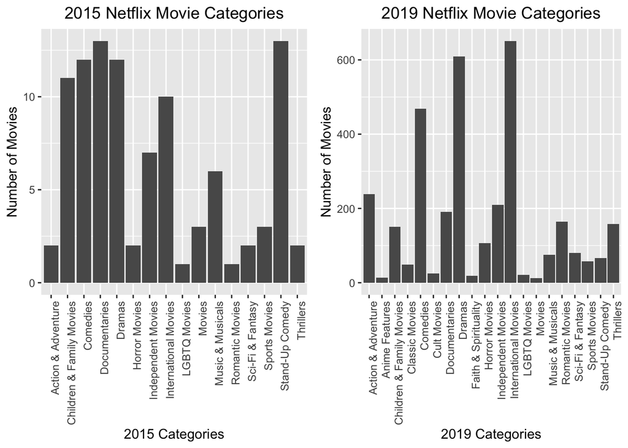

This chart was included to show the change in netflix movie categories over time. In 2015, the most popular movie categories were Stand-up Comedy and Documentaries. In 2019, however, the most popular movie category has become International Movies. There are also the addition of 4 new categories: Anime Features, Classic Movies, Cult Movies, and Faith and Spirituality. The number of movies increased significantly for each categories, as shown by the y axis units, and the variety of categories also expanded throughout time.

## Chart 3:

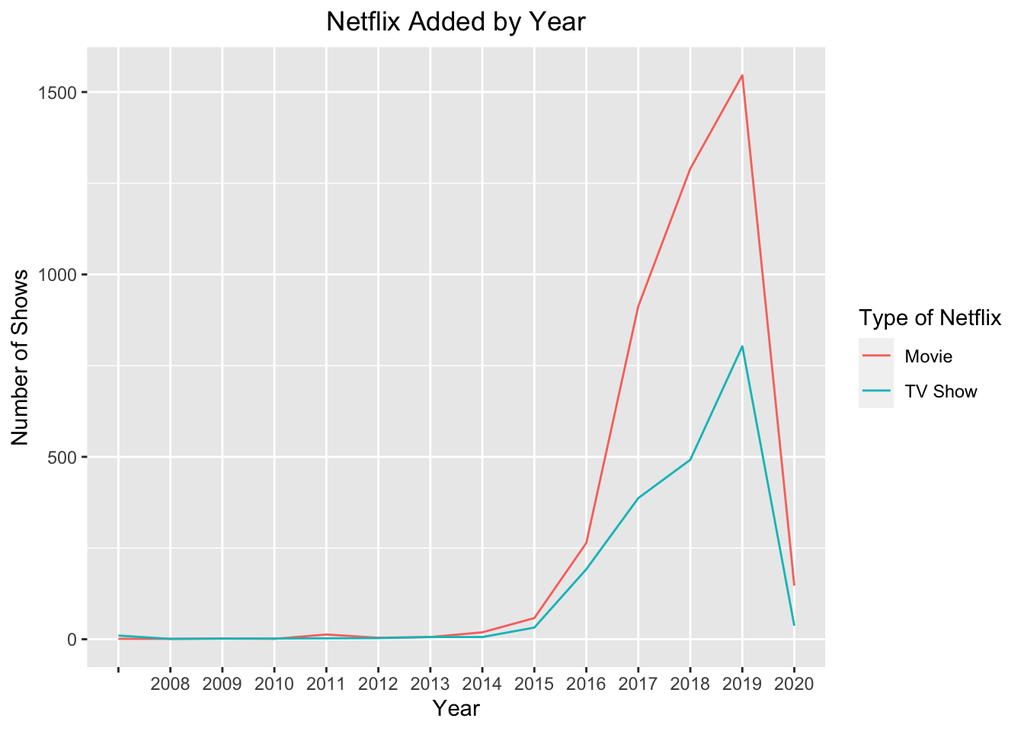

This chart was included to show the number of netflix shows added throughout the years. From the graph, we can see that there is generally an increasing trend throughout the years, reaching a maximum in 2019. I would expect the trend to continue in the year 2020, but because the dataset only updates to January 18, 2020, there is a sufficient lack in data for 2020, causing a decrease. Otherwise, the number of netflix shows is definitely increasing as time passes, especially the recent years.